# ワーキングメモリ課題における記憶負荷（N-Back）が反応時間および正答率に及ぼす影響

佐藤 愛心（2412B07）

## 1. 目的 (Introduction)

普段私たちは生活を行う上で、相手が話した内容を覚えながらメモを取ったり、複数ある指示を記憶に留めて作業を行っている。これは情報を一時的に保持しながら同時に処理する「ワーキングメモリ（作業記憶）」が作用しているためであり、一般にはあまり耳にしないが私たちにとって、とても身近な存在である。しかし、同時にこなすべき作業が増えたり、求められる認知的負荷が高まったりすると、私たちのパフォーマンスは急激に低下することが経験的にも知られている。こうしたワーキングメモリの容量限界や、負荷の増大が認知処理に与える影響を測定するため、本研究では、N-back課題におけるワーキングメモリ（作業記憶）への負荷（1-Back条件.2-Back条件）が高まると、反応時間および正答率はどのように変化するか、について検討する。

## 2. 方法 (Method)

### 参加者

当初20名程度の参加を想定して募集を行ったところ、36名から回答が得られた。得られたデータに対してスクリーニングおよび不備の確認を行った結果、欠損値等のあるデータを除外した26名（平均年齢は 42.35 歳、SD = 14.58）を最終的な分析対象とした。なお、本実験では属性情報として年齢のみを尋ねた。

### 装置と材料

実験プログラムの作成には、オンライン実験用JavaScriptライブラリであるjsPsychおよびWeb開発技術（HTML/CSS/JavaScript）を用いた。実験は自作のポータルサイト上でホスティングされ、参加者は自身の所有するパーソナルコンピュータ（PC）、スマートフォン、またはタブレット端末のいずれかを使用してWebブラウザ経由でアクセスし、実験に参加した。

### 手続き

実験の手続きとして、参加者は1-Back条件および2-Back条件の課題を実施した。 各試行では、画面中央にアルファベットが500ミリ秒間提示し、参加者は提示された文字に対する判断を行い、対応するボタン（またはキー）を用いて回答することを求められた。 1試行の総時間は2000ミリ秒と定められており、刺激の提示後、制限時間（または残りの時間）が経過して合計2000ミリ秒に達した時点で自動的に次の試行へと移行した。 すべての試行が終了すると、実験終了の教示とともに参加者自身のスコアが画面に表示され、実験は終了した。

## 3. 結果 (Results)

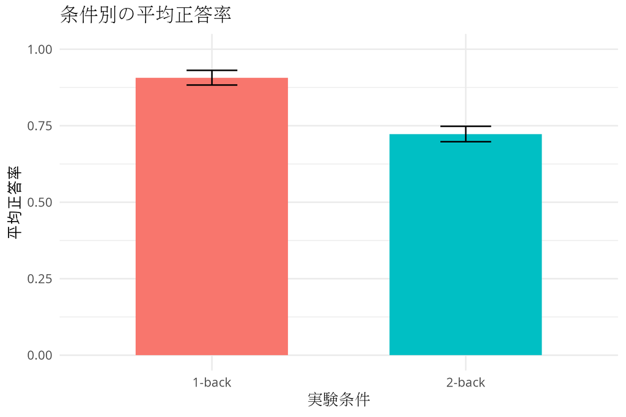

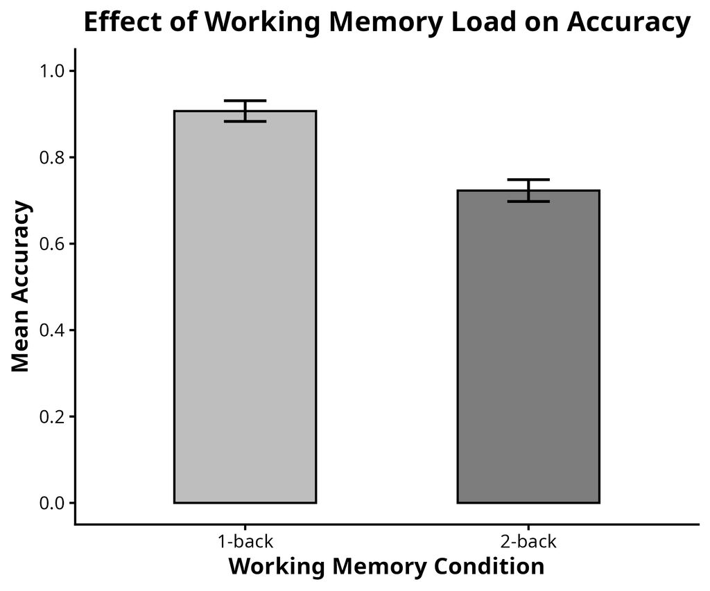